# Exercise5

On February 9, 2014, Swiss voters accepted the initiative Mass Immigration". In this exercise, we will try to predict the acceptance in each canton based on goegraphic and demographic data.

The data set massimmigration.csv available in ILIAS contains the following variables:

- canton: abbreviation of the canton
- yes: acceptance (fraction of " votes) in % (response variable)
- area: area im km2
- inhabitants: inhabitants of the canton
- foreigners: fraction of foreigners in %

```r
mi <- read.table("../datasets/massimmigration.csv", header = TRUE, sep = "\t")
rownames(mi) <- mi$canton
mi$canton <- NULL
summary(mi)
```

```
##       area         inhabitants        foreigners         yes
##  Min.   :  37.0   Min.   :  15789   Min.   : 9.90   Min.   :38.90
##  1st Qu.: 346.2   1st Qu.:  72695   1st Qu.:15.15   1st Qu.:48.35
##  Median : 873.0   Median : 225437   Median :21.20   Median :53.85
##  Mean   :1587.9   Mean   : 309825   Mean   :20.98   Mean   :52.55
##  3rd Qu.:1714.5   3rd Qu.: 374975   3rd Qu.:24.55   3rd Qu.:58.17
##  Max.   :7105.0   Max.   :1408575   Max.   :37.20   Max.   :68.20
```

```r
mi.fit <- lm(yes ~ foreigners, data = mi)
summary(mi.fit)
```

```
##
## Call:
## lm(formula = yes ~ foreigners, data = mi)
##
## Residuals:
##     Min      1Q  Median      3Q     Max
## -13.065  -4.070  -1.034   4.179  19.405
##
## Coefficients:
##             Estimate Std. Error t value Pr(>|t|)
## (Intercept)  64.8317     4.4174  14.676 1.74e-13 ***
## foreigners   -0.5853     0.2001  -2.925   0.0074 **
## ---
## Signif. codes:  0 '***' 0.001 '**' 0.01 '*' 0.05 '.' 0.1 ' ' 1
##
## Residual standard error: 7.006 on 24 degrees of freedom
## Multiple R-squared:  0.2629, Adjusted R-squared:  0.2321
## F-statistic: 8.558 on 1 and 24 DF,  p-value: 0.007404
```

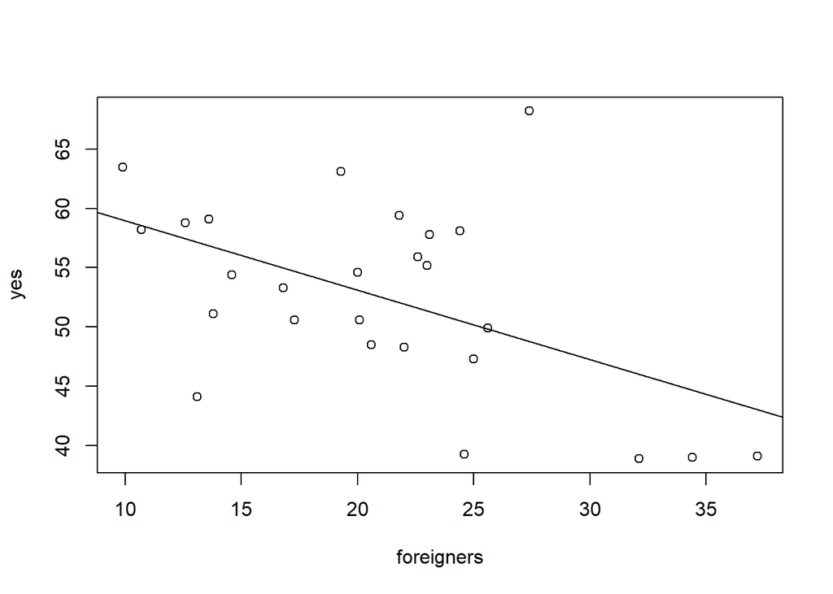

```r
plot(yes ~ foreigners, data = mi)
abline(mi.fit)
```

QQplot and Tuckey-Anscombe plot to analyse the residuals:

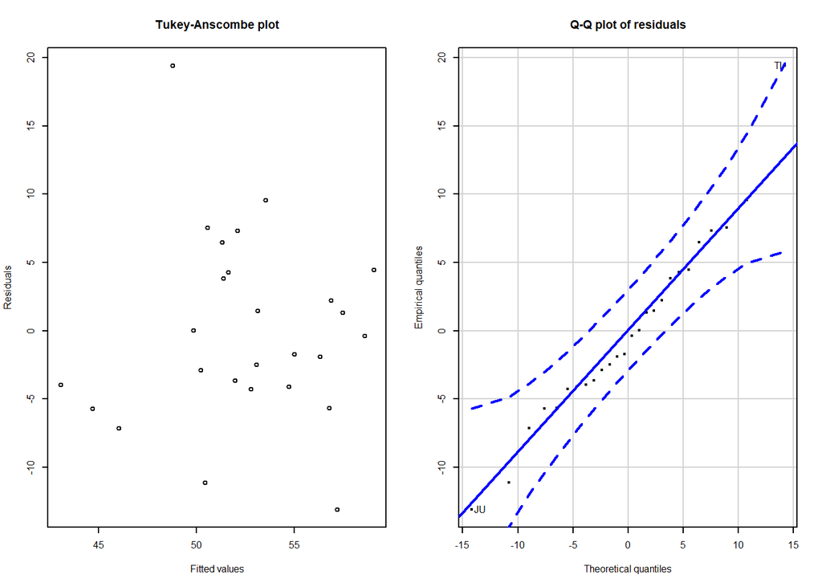

```
## TI JU
## 20 11
```

```r
par(mfrow = c(1, 2), cex = 0.5)
plot(fitted(mi.fit),
     resid(mi.fit),
     xlab = "Fitted values",
     ylab = "Residuals",
     main = "Tukey-Anscombe plot")

qqPlot(resid(mi.fit),
       dist = "norm",
       mean = mean(resid(mi.fit)),
       sd = sd(resid(mi.fit)),
       xlab = "Theoretical quantiles",
       ylab = "Empirical quantiles",
       main = "Q-Q plot of residuals")
```

Both plots look good.

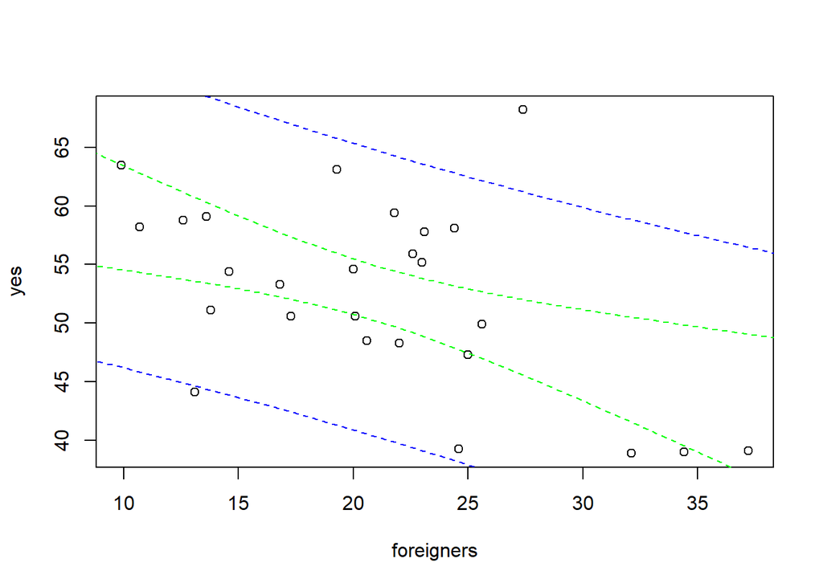

```r
mi <- read.table("../datasets/massimmigration.csv", header = TRUE, sep = "\t")
rownames(mi) <- mi$canton
mi$canton <- NULL

plot.new()
plot(yes ~ foreigners, data = mi)
x.val <- seq(0, 40, by = 1)
mi.fit <- lm(yes ~ foreigners, data = mi)
pred.band <- predict(mi.fit, level = 0.9, newdata = data.frame(foreigners = x.val), interval = "prediction")
conf.band <- predict(mi.fit, level = 0.9, newdata = data.frame(foreigners = x.val), interval = "confidence")

lines(x.val, pred.band[, "lwr"], col = "blue", lty = 2)
lines(x.val, pred.band[, "upr"], col = "blue", lty = 2)
lines(x.val, conf.band[, "lwr"], col = "green", lty = 2)
lines(x.val, conf.band[, "upr"], col = "green", lty = 2)
```

```r
summary(mi.fit)
```

```
##
## Call:
## lm(formula = yes ~ foreigners, data = mi)
##
## Residuals:
##     Min      1Q  Median      3Q     Max
## -13.065  -4.070  -1.034   4.179  19.405
##
## Coefficients:
##             Estimate Std. Error t value Pr(>|t|)
## (Intercept)  64.8317     4.4174  14.676 1.74e-13 ***
## foreigners   -0.5853     0.2001  -2.925   0.0074 **
## ---
## Signif. codes:  0 '***' 0.001 '**' 0.01 '*' 0.05 '.' 0.1 ' ' 1
##
## Residual standard error: 7.006 on 24 degrees of freedom
## Multiple R-squared:  0.2629, Adjusted R-squared:  0.2321
## F-statistic: 8.558 on 1 and 24 DF,  p-value: 0.007404
```

The Confidence band indicates the accuracy of estimation of the true regression line. Meaning, the true regression line is in the green area with a 90% confidence.

The Prediction interval indicates, between which boundaries the y-value of a new measurement will be with certainty 1-alpha, at position x. Meaning, in 90% of the cases, the y value will be between the blue lines.

## c

How well does the fraction of foreigners explain the acceptance in the different cantons? Calculate the coeficient of determination R2 and the F statistic “by hand”, i.e. only using the R functions resid, fitted and mean. Check your results with the output of summary.

The output of summary gives an R2 of 0.2629.

```r
yhat <- fitted(mi.fit)
ybar <- mean(mi$yes)
(R.sq <- sum((yhat - ybar)^2)/sum((mi$yes - ybar)^2))
```

```
## [1] 0.2628564
```

For the F-Statistic given by summary is 8.558

```r
n <- nrow(mi)
q <- 2
(F <- sum((yhat - ybar)^2)*(n - q)/sum((mi$yes - yhat)^2)/(q - 1))
```

```
## [1] 8.558108
```

## d

Select the best linear model as follows: 1. Add a variable density to the data set, defined as the number of inhabitants per area. 2. Start with the full regression model. 3. As long as there is an explanatory variable with a p-value above 5%: - Remove the least significant variable. - Keep the new model if the larger model is not significantly better based on an F-test.

```r
mi$density <- mi$inhabitants/mi$area
mi.full <- lm(yes ~ ., data = mi)
summary(mi.full)
```

```
##
## Call:
## lm(formula = yes ~ ., data = mi)
##
## Residuals:
##      Min       1Q   Median       3Q      Max
## -13.6334  -2.7179   0.5134   4.2234  17.7448
##
## Coefficients:
##               Estimate Std. Error t value Pr(>|t|)
## (Intercept)  6.281e+01  5.026e+00  12.499 3.42e-11 ***
## area        -5.972e-04  8.599e-04  -0.695    0.495
## inhabitants -3.474e-06  5.018e-06  -0.692    0.496
## foreigners  -3.353e-01  2.573e-01  -1.303    0.207
## density     -2.513e-03  1.693e-03  -1.484    0.153
## ---
## Signif. codes:  0 '***' 0.001 '**' 0.01 '*' 0.05 '.' 0.1 ' ' 1
##
## Residual standard error: 6.983 on 21 degrees of freedom
## Multiple R-squared:  0.3593, Adjusted R-squared:  0.2373
## F-statistic: 2.945 on 4 and 21 DF,  p-value: 0.0445
```

```r
mi.red1 <- update(mi.full, . ~ . - inhabitants)
anova(mi.red1, mi.full)
```

```
## Analysis of Variance Table
##
## Model 1: yes ~ area + foreigners + density
## Model 2: yes ~ area + inhabitants + foreigners + density
##   Res.Df    RSS Df Sum of Sq      F Pr(>F)
## 1     22 1047.3
## 2     21 1024.0  1    23.366 0.4792 0.4964
```

```r
summary(mi.red1)
```

```
##
## Call:
## lm(formula = yes ~ area + foreigners + density, data = mi)
##
## Residuals:
##      Min       1Q   Median       3Q      Max
## -13.1777  -2.6501   0.1105   3.6335  18.3475
##
## Coefficients:
##               Estimate Std. Error t value Pr(>|t|)
## (Intercept) 63.3799985  4.8999629  12.935 9.29e-12 ***
## area        -0.0008504  0.0007690  -1.106    0.281
## foreigners  -0.3955019  0.2393073  -1.653    0.113
## density     -0.0024644  0.0016717  -1.474    0.155
## ---
## Signif. codes:  0 '***' 0.001 '**' 0.01 '*' 0.05 '.' 0.1 ' ' 1
##
## Residual standard error: 6.9 on 22 degrees of freedom
## Multiple R-squared:  0.3447, Adjusted R-squared:  0.2554
## F-statistic: 3.858 on 3 and 22 DF,  p-value: 0.02334
```

```r
mi.red2 <- update(mi.red1, . ~ . - area)

summary(mi.red2)
```

```
##
## Call:
## lm(formula = yes ~ foreigners + density, data = mi)
##
## Residuals:
##      Min       1Q   Median       3Q      Max
## -12.5467  -4.3562  -0.1261   3.5218  17.6284
##
## Coefficients:
##              Estimate Std. Error t value Pr(>|t|)
## (Intercept) 62.313648   4.827398  12.908 5.08e-12 ***
## foreigners  -0.419684   0.239459  -1.753    0.093 .
## density     -0.001998   0.001625  -1.229    0.231
## ---
## Signif. codes:  0 '***' 0.001 '**' 0.01 '*' 0.05 '.' 0.1 ' ' 1
##
## Residual standard error: 6.933 on 23 degrees of freedom
## Multiple R-squared:  0.3083, Adjusted R-squared:  0.2481
## F-statistic: 5.126 on 2 and 23 DF,  p-value: 0.01442
```

In the next step, we would get back the model fitted in task a).